# FML_Assignment_2

Chakri

2023-09-28

```r
library(class)
library(caret)
library(e1071)
```

#importing the data from the directory

```r
uni_bank.df <- read.csv("H:\\Kent Sem-1\\FML\\FML_class\\UniversalBank.csv")
#uni_bank.df
```

#idnetifying the rows and columns and head and tail of the data

```r
dim(uni_bank.df)
```

```
## [1] 5000   14
```

```r
t(t(names(uni_bank.df)))
```

```
##       [,1]
##  [1,] "ID"
##  [2,] "Age"
##  [3,] "Experience"
##  [4,] "Income"
##  [5,] "ZIP.Code"
##  [6,] "Family"
##  [7,] "CCAvg"
##  [8,] "Education"
##  [9,] "Mortgage"
## [10,] "Personal.Loan"
## [11,] "Securities.Account"
## [12,] "CD.Account"
## [13,] "Online"
## [14,] "CreditCard"
```

```r
head(uni_bank.df)
```

```
##   ID Age Experience Income ZIP.Code Family CCAvg Education Mortgage
## 1  1  25          1     49    91107      4   1.6         1        0
## 2  2  45         19     34    90089      3   1.5         1        0
## 3  3  39         15     11    94720      1   1.0         1        0
## 4  4  35          9    100    94112      1   2.7         2        0
## 5  5  35          8     45    91330      4   1.0         2        0
## 6  6  37         13     29    92121      4   0.4         2      155
##   Personal.Loan Securities.Account CD.Account Online CreditCard
## 1             0                  1          0      0          0
## 2             0                  1          0      0          0
## 3             0                  0          0      0          0
## 4             0                  0          0      0          0
## 5             0                  0          0      0          1
## 6             0                  0          0      1          0
```

```r
tail(uni_bank.df)
```

```
##        ID Age Experience Income ZIP.Code Family CCAvg Education Mortgage
## 4995 4995  64         40     75    94588      3   2.0         3        0
## 4996 4996  29          3     40    92697      1   1.9         3        0
## 4997 4997  30          4     15    92037      4   0.4         1       85
## 4998 4998  63         39     24    93023      2   0.3         3        0
## 4999 4999  65         40     49    90034      3   0.5         2        0
## 5000 5000  28          4     83    92612      3   0.8         1        0
##      Personal.Loan Securities.Account CD.Account Online CreditCard
## 4995             0                  0          0      1          0
## 4996             0                  0          0      1          0
## 4997             0                  0          0      1          0
## 4998             0                  0          0      0          0
## 4999             0                  0          0      1          0
## 5000             0                  0          0      1          1
```

#Drop unnecessary rows like ID and Zip

```r
uni_bank.df <- uni_bank.df[,-c(1,5)]
```

#Categorical varables will be converted as factor(ie,. Education) as mentioned in the question

```r
uni_bank.df$Education <- as.factor(uni_bank.df$Education)
```

#now converting the Education into dummy variables

```r
groups <- dummyVars(~., data = uni_bank.df)
#the new data frame is named as modified universal bank data
uni_bank.m.df <- as.data.frame(predict(groups,uni_bank.df))
```

#splitting the data for training data(60%) and validation data(remaining 40%)

```r
#it is important to ensure that that we get the same sample if we return the code multiple times
set.seed(7)
#dividing the data into 60% training data and remaining data to validation
train.data <- sample(row.names(uni_bank.m.df),0.6*dim(uni_bank.m.df)[1])
valid.data <- setdiff(row.names(uni_bank.m.df),train.data)

#apply the model
#all the variables are taking in after the seperated comma
train.df <- uni_bank.m.df[train.data,]
valid.df <- uni_bank.m.df[valid.data,]
t(t(names(train.df)))
```

```
##       [,1]
##  [1,] "Age"
##  [2,] "Experience"
##  [3,] "Income"
##  [4,] "Family"
##  [5,] "CCAvg"
##  [6,] "Education.1"
##  [7,] "Education.2"
##  [8,] "Education.3"
##  [9,] "Mortgage"
## [10,] "Personal.Loan"
## [11,] "Securities.Account"
## [12,] "CD.Account"
## [13,] "Online"
## [14,] "CreditCard"
```

#normalizing the data

```r
train.norm.df <- train.df[,-10]
valid.norm.df <- valid.df[,-10]#personal income is the 10th variable

norm.values <- preProcess(train.df[,-10], method = c("center","scale"))

#mean and standard deviation is coming from the train data

train.norm.df <- predict(norm.values,train.df[,-10])
valid.norm.df <- predict(norm.values,valid.df[,-10])
```

#1. Age = 40, Experience = 10, Income = 84, Family = 2, CCAvg = 2, Education_1 = 0, Education_2 =1, Education_3 = 0, Mortgage = 0, Securities Account = 0, CD Account = 0, Online = 1, and Credit Card = 1. Perform a k-NN classification with all predictors except ID and ZIP code using k = 1. Remember to transform categorical predictors with more than two categories into dummy variables first. Specify the success class as 1 (loan acceptance), and use the default cutoff value of 0.5. How would this customer be classified?

#creating the new customer and with knn-prediction

```r
new_customer <- data.frame(Age = 40,
Experience = 10,
Income = 84,
Family = 2,
CCAvg = 2,
Education.1 = 0,
Education.2 = 1,
Education.3 = 0,
Mortgage = 0,
Securities.Account = 0,
CD.Account = 0,
Online = 1,
CreditCard = 1
)
```

#now normalize the data for the new customer

```r
new.cust.norm <- new_customer
new.cust.norm <- predict(norm.values,new.cust.norm)
```

```r
knn.pred1 <- class::knn(train= train.norm.df,
                        test = new.cust.norm,
                        cl= train.df$Personal.Loan, k=1 )
knn.pred1
```

```
## [1] 0
## Levels: 0 1
```

#2.What is a choice of k that balances between overfitting and ignoring the predictor information?

```r
accuracy.df <- data.frame(k= seq(1,15,1), overallaccuracy= rep(0,15))
for(i in 1:15){
  knn.pred <- class::knn(train=train.norm.df, test = valid.norm.df, cl= train.df$Personal.Loan, k=i)
  accuracy.df[i,2] <- confusionMatrix(knn.pred, as.factor(valid.df$Personal.Loan), positive= "1")$overall[1]
}

which(accuracy.df[,2]== max(accuracy.df[,2]))
```

```
## [1] 3
```

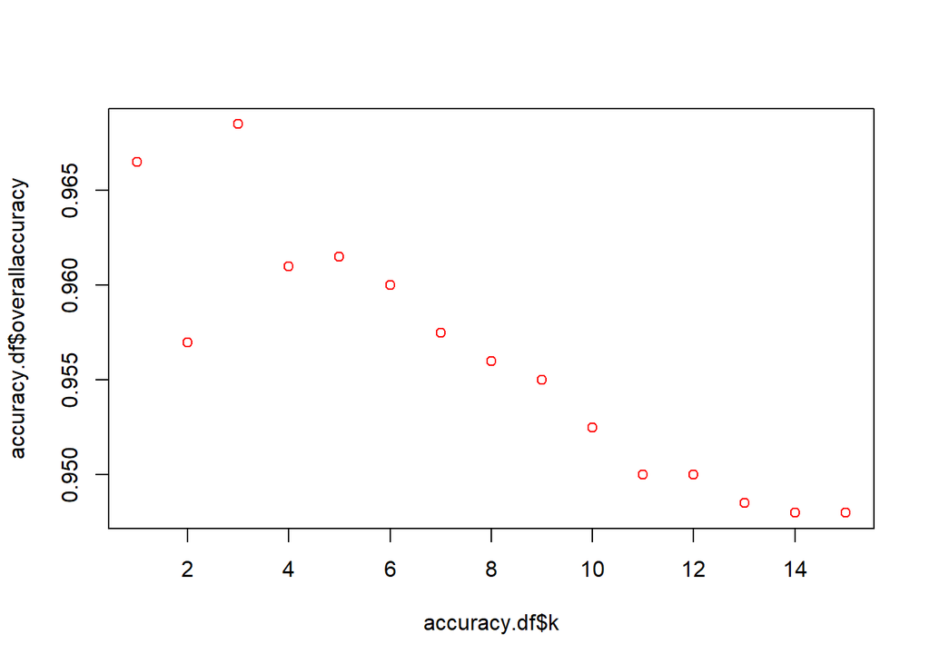

```r
plot(accuracy.df$k,accuracy.df$overallaccuracy,col="red")
```

#3. Show the confusion matrix for the validation data that results from using the best k?

```r
knn.pred2 <- class::knn(train = train.norm.df, test = valid.norm.df, cl= train.df$Personal.Loan, k=3)
con.mat <-confusionMatrix(table(knn.pred2,as.factor(valid.df$Personal.Loan)))
con.mat
```

```
## Confusion Matrix and Statistics
##
##
## knn.pred2    0    1
##         0 1814   53
##         1   10  123
##
##                Accuracy : 0.9685
##                  95% CI : (0.9599, 0.9757)
##     No Information Rate : 0.912
##     P-Value [Acc > NIR] : < 2.2e-16
##
##                   Kappa : 0.7794
##
##  Mcnemar's Test P-Value : 1.213e-07
##
##             Sensitivity : 0.9945
##             Specificity : 0.6989
##          Pos Pred Value : 0.9716
##          Neg Pred Value : 0.9248
##              Prevalence : 0.9120
##          Detection Rate : 0.9070
##    Detection Prevalence : 0.9335
##       Balanced Accuracy : 0.8467
##
##        'Positive' Class : 0
##
```

#4. Consider the following customer: Age = 40, Experience = 10, Income = 84, Family = 2, CCAvg = 2, Education_1 = 0, Education_2 = 1, Education_3 = 0, Mortgage = 0, Securities Account = 0, CD Account = 0, Online = 1 and Credit Card = 1. Classify the customer using the best k.

```r
new_customer1 <- data.frame(Age = 40,
                            Experience = 10,
                            Income = 84,
                            Family = 2,
                            CCAvg = 2,
                            Education.1 = 0,
                            Education.2 = 1,
                            Education.3 = 0,
                            Mortgage = 0,
                            Securities.Account = 0,
                            CD.Account = 0,
                            Online = 1,
                            CreditCard = 1)

new.cust.norm1 <- new_customer1
new.cust.norm1 <- predict(norm.values,new.cust.norm1)

knn.pred3 <- class::knn(train = train.norm.df, test = new.cust.norm1, cl= train.df$Personal.Loan,k= 3)
knn.pred3
```

```
## [1] 0
## Levels: 0 1
```

#5.Repartition the data, this time into training, validation, and test sets (50% : 30% : 20%). Apply the k-NN method with the k chosen above. Compare the confusion matrix of the test set with that of the training and validation sets. Comment on the differences and their reason.

#it is important to ensure that that we get the same sample if we return the code multiple times #splitting the data to training(50%), validation(30%) and testing(remaining 20%)

```r
set.seed(26)
train.data1 <- sample(row.names(uni_bank.m.df),0.5*dim(uni_bank.m.df)[1])
train.df1 <- uni_bank.m.df[as.numeric(train.data1),]

valid.data0 <- setdiff(row.names(uni_bank.m.df),train.data1)
valid.df0 <- uni_bank.m.df[as.numeric(valid.data0),]
valid.data1 <- sample(row.names(valid.df0),0.6*dim(valid.df0)[1])
test.data1 <- setdiff(row.names(valid.df0),valid.data1)

valid.df1 <- uni_bank.m.df[valid.data1,]
test.df1 <- uni_bank.m.df[test.data1,]

t(t(names(train.df1)))
```

```
##       [,1]
##  [1,] "Age"
##  [2,] "Experience"
##  [3,] "Income"
##  [4,] "Family"
##  [5,] "CCAvg"
##  [6,] "Education.1"
##  [7,] "Education.2"
##  [8,] "Education.3"
##  [9,] "Mortgage"
## [10,] "Personal.Loan"
## [11,] "Securities.Account"
## [12,] "CD.Account"
## [13,] "Online"
## [14,] "CreditCard"
```

#normalizing the data

```r
train.norm.df1 <- train.df1[,-10]
valid.norm.df1 <- valid.df1[,-10]
test.norm.df1 <- test.df1[,-10]

norm.values1 <- preProcess(train.df1[,-10], method = c("center","scale"))

train.norm.df1 <- predict(norm.values1,train.df1[,-10])
valid.norm.df1 <- predict(norm.values,valid.df1[,-10])
test.norm.df1 <- predict(norm.values1,test.df1[,-10])
```

#confusion matrix for the training data

```r
knn.pred4 <- class::knn(train = train.norm.df1,
                        test = train.norm.df1,
                        cl= train.df1$Personal.Loan, k= 3)
knn.pred4
```

[output not shown]

[output cut: 54 more lines]

```r
con.mat4 <- confusionMatrix(knn.pred4, as.factor(train.df1$Personal.Loan))
con.mat4
```

```
## Confusion Matrix and Statistics
##
##           Reference
## Prediction    0    1
##          0 2254   64
##          1    3  179
##
##                Accuracy : 0.9732
##                  95% CI : (0.9661, 0.9792)
##     No Information Rate : 0.9028
##     P-Value [Acc > NIR] : < 2.2e-16
##
##                   Kappa : 0.828
##
##  Mcnemar's Test P-Value : 2.299e-13
##
##             Sensitivity : 0.9987
##             Specificity : 0.7366
##          Pos Pred Value : 0.9724
##          Neg Pred Value : 0.9835
##              Prevalence : 0.9028
##          Detection Rate : 0.9016
##    Detection Prevalence : 0.9272
##       Balanced Accuracy : 0.8676
##
##        'Positive' Class : 0
##
```

From the training data shows the model ability to learn from the training data with highest accuracy and sensitivity results in overfitting.

#confusion matrix for the validation data

```r
knn.pred5 <- class::knn(train = train.norm.df1,
                        test = valid.norm.df1,
                        cl= train.df1$Personal.Loan, k= 3)
knn.pred5
```

[output not shown]

[output cut: 27 more lines]

```r
con.mat5 <- confusionMatrix(knn.pred5, as.factor(valid.df1$Personal.Loan))
con.mat5
```

```
## Confusion Matrix and Statistics
##
##           Reference
## Prediction    0    1
##          0 1354   57
##          1    3   86
##
##                Accuracy : 0.96
##                  95% CI : (0.9488, 0.9693)
##     No Information Rate : 0.9047
##     P-Value [Acc > NIR] : 2.751e-16
##
##                   Kappa : 0.721
##
##  Mcnemar's Test P-Value : 7.795e-12
##
##             Sensitivity : 0.9978
##             Specificity : 0.6014
##          Pos Pred Value : 0.9596
##          Neg Pred Value : 0.9663
##              Prevalence : 0.9047
##          Detection Rate : 0.9027
##    Detection Prevalence : 0.9407
##       Balanced Accuracy : 0.7996
##
##        'Positive' Class : 0
##
```

#confusion matrix for the testing data

```r
knn.pred6 <- class::knn(train = train.norm.df1,
                        test = test.norm.df1,
                        cl= train.df1$Personal.Loan, k= 3)
knn.pred6
```

[output not shown]

```r
con.mat6 <- confusionMatrix(knn.pred6, as.factor(test.df1$Personal.Loan))
con.mat6
```

```
## Confusion Matrix and Statistics
##
##           Reference
## Prediction   0   1
##          0 901  27
##          1   5  67
##
##                Accuracy : 0.968
##                  95% CI : (0.9551, 0.978)
##     No Information Rate : 0.906
##     P-Value [Acc > NIR] : 1.465e-14
##
##                   Kappa : 0.7901
##
##  Mcnemar's Test P-Value : 0.0002054
##
##             Sensitivity : 0.9945
##             Specificity : 0.7128
##          Pos Pred Value : 0.9709
##          Neg Pred Value : 0.9306
##              Prevalence : 0.9060
##          Detection Rate : 0.9010
##    Detection Prevalence : 0.9280
##       Balanced Accuracy : 0.8536
##
##        'Positive' Class : 0
##
```

From the test data where it confirms the real-world scenarios with high accuracy and sensitivity eventhough the specificity slightly reduced.

Finally, the above model demonstrates good balance between overfitting and ignoring predictor information. it fits the training data and the model can take the knowledge from the training data and applying it to unseen data, and also the model is not only memorizing the data but instead learning the patterns that can be applied in real world scenarios